# Cereal Nutrition by Mark Robert Dods

### Introduction:

I chose the ‘80 cereals’ dataset that I found on Kaggle (https://www.kaggle.com/crawford/80-cereals). I chose it because it had 16 different variables (13 dependent, 3 independent) associated with each cereal which I could compare to see which ones are correlated. I focused mainly on sugar, fat, sodium, and fiber, and investigated 1) which manufacturer makes the most healthy or unhealthy cereal, and 2) which variable most affects the overall rating given to the cereal. I then created a model to predict rating based on the sugar, fat, sodium, and fiber content of a particular cereal.

### Fields in the dataset:

- Name: Name of cereal
- manufacturer: manufacturer of cereal
  - A = American Home Food Products
  - G = General Mills
  - K = Kelloggs
  - N = Nabisco
  - P = Post
  - Q = Quaker Oats
  - R = Ralston Purina
- type:
  - cold
  - hot
- calories: calories per serving
- protein: grams of protein
- fat: grams of fat
- sodium: milligrams of sodium
- fiber: grams of dietary fiber
- carbo: grams of complex carbohydrates
- sugars: grams of sugars
- potass: milligrams of potassium
- vitamins: vitamins and minerals - 0, 25, or 100, indicating the typical percentage of FDA recommended
- shelf: display shelf
- weight: weight in ounces of one serving
- cups: number of cups in one serving
- rating: a rating of the cereals

## Univariate Plots Section

Number of rows in dataset

```
## [1] 76
```

Summary of data type for each variable in dataset

```
## 'data.frame':    76 obs. of  23 variables:
##  $ name         : Factor w/ 77 levels "100% Bran","100% Natural Bran",..: 1 2 3 4 5 6 7 8 9 10 ...
##  $ manufacturer : Factor w/ 7 levels "A","General Mills",..: 4 6 3 3 7 2 3 2 7 5 ...
##  $ type         : Factor w/ 2 levels "C","H": 1 1 1 1 1 1 1 1 1 1 ...
##  $ calories     : int  70 120 70 50 110 110 110 130 90 90 ...
##  $ protein      : int  4 3 4 4 2 2 2 3 2 3 ...
##  $ fat          : int  1 5 1 0 2 2 0 2 1 0 ...
##  $ sodium       : int  130 15 260 140 200 180 125 210 200 210 ...
##  $ fiber        : num  10 2 9 14 1 1.5 1 2 4 5 ...
##  $ carbo        : num  5 8 7 8 14 10.5 11 18 15 13 ...
##  $ sugars       : int  6 8 5 0 8 10 14 8 6 5 ...
##  $ potass       : int  280 135 320 330 -1 70 30 100 125 190 ...
##  $ vitamins     : int  25 0 25 25 25 25 25 25 25 25 ...
##  $ shelf        : int  3 3 3 3 3 1 2 3 1 3 ...
##  $ weight       : num  1 1 1 1 1 1 1 1.33 1 1 ...
##  $ cups         : num  0.33 1 0.33 0.5 0.75 0.75 1 0.75 0.67 0.67 ...
##  $ rating       : num  68.4 34 59.4 93.7 34.4 ...
##  $ SugarsToFiber: num  0.6 4 0.556 0 8 ...
##  $ SugarsToFat  : num  6 1.6 5 NaN 4 ...
##  $ WeightInGrams: num  28.3 28.3 28.3 28.3 28.3 ...
##  $ PercFat      : num  0.0353 0.1764 0.0353 0 0.0705 ...
##  $ PercSodium   : num  4.586 0.529 9.171 4.938 7.055 ...
##  $ PercSugar    : num  0.212 0.282 0.176 0 0.282 ...
##  $ PercFiber    : num  0.3527 0.0705 0.3175 0.4938 0.0353 ...
```

Summary stats for all variables in dataset

```
##                         name            manufacturer type      calories
##  100% Bran                : 1   A             : 0    C:74   Min.   : 50
##  100% Natural Bran        : 1   General Mills :22    H: 2   1st Qu.:100
##  All-Bran                 : 1   Kelloggs      :23           Median :110
##  All-Bran with Extra Fiber: 1   Nabisco       : 6           Mean   :107
##  Almond Delight           : 1   Post          : 9           3rd Qu.:110
##  Apple Cinnamon Cheerios  : 1   Quaker Oats   : 8           Max.   :160
##  (Other)                  :70   Ralston Purina: 8
##     protein           fat            sodium          fiber
##  Min.   :1.000   Min.   :0.000   Min.   :  0.0   Min.   : 0.00
##  1st Qu.:2.000   1st Qu.:0.000   1st Qu.:133.8   1st Qu.: 1.00
##  Median :2.500   Median :1.000   Median :180.0   Median : 2.00
##  Mean   :2.526   Mean   :1.013   Mean   :161.8   Mean   : 2.18
##  3rd Qu.:3.000   3rd Qu.:2.000   3rd Qu.:212.5   3rd Qu.: 3.00
##  Max.   :6.000   Max.   :5.000   Max.   :320.0   Max.   :14.00
##
##      carbo           sugars           potass          vitamins
##  Min.   :-1.00   Min.   :-1.000   Min.   : -1.00   Min.   :  0.00
##  1st Qu.:12.00   1st Qu.: 3.000   1st Qu.: 40.00   1st Qu.: 25.00
##  Median :14.00   Median : 7.000   Median : 90.00   Median : 25.00
##  Mean   :14.58   Mean   : 6.974   Mean   : 96.09   Mean   : 28.29
##  3rd Qu.:17.00   3rd Qu.:11.000   3rd Qu.:120.00   3rd Qu.: 25.00
##  Max.   :23.00   Max.   :15.000   Max.   :330.00   Max.   :100.00
##
##      shelf           weight          cups            rating
##  Min.   :1.000   Min.   :0.50   Min.   :0.2500   Min.   :18.04
##  1st Qu.:1.000   1st Qu.:1.00   1st Qu.:0.6700   1st Qu.:32.93
##  Median :2.000   Median :1.00   Median :0.7500   Median :40.25
##  Mean   :2.211   Mean   :1.03   Mean   :0.8187   Mean   :42.51
##  3rd Qu.:3.000   3rd Qu.:1.00   3rd Qu.:1.0000   3rd Qu.:50.78
##  Max.   :3.000   Max.   :1.50   Max.   :1.5000   Max.   :93.70
##
##  SugarsToFiber      SugarsToFat   WeightInGrams      PercFat
##  Min.   :-0.3704   Min.   :-0.5   Min.   :14.17   Min.   :0.00000
##  1st Qu.: 1.6667   1st Qu.: 4.0   1st Qu.:28.35   1st Qu.:0.00000
##  Median : 3.5000   Median : 9.0   Median :28.35   Median :0.03527
##  Mean   :    Inf   Mean   : Inf   Mean   :29.20   Mean   :0.03410
##  3rd Qu.:13.5000   3rd Qu.: Inf   3rd Qu.:28.35   3rd Qu.:0.04853
##  Max.   :    Inf   Max.   : Inf   Max.   :42.52   Max.   :0.17637
##  NA's   :1         NA's   :7
##    PercSodium       PercSugar          PercFiber
##  Min.   : 0.000   Min.   :-0.03527   Min.   :0.00000
##  1st Qu.: 4.453   1st Qu.: 0.10582   1st Qu.:0.03527
##  Median : 5.702   Median : 0.21191   Median :0.06241
##  Mean   : 5.481   Mean   : 0.23289   Mean   :0.07334
##  3rd Qu.: 7.143   3rd Qu.: 0.35274   3rd Qu.:0.10582
##  Max.   :11.288   Max.   : 0.52911   Max.   :0.49384
##
```

Number of cereals in dataset by manufacturer

```
##              A  General Mills       Kelloggs        Nabisco           Post
##              0             22             23              6              9
##    Quaker Oats Ralston Purina
##              8              8
```

Distributions of selected nutritional variables

Note: All statistical outliers have been included as they are valid values (as opposed to abnormal ones) within the distributions and are significant to the dataset.

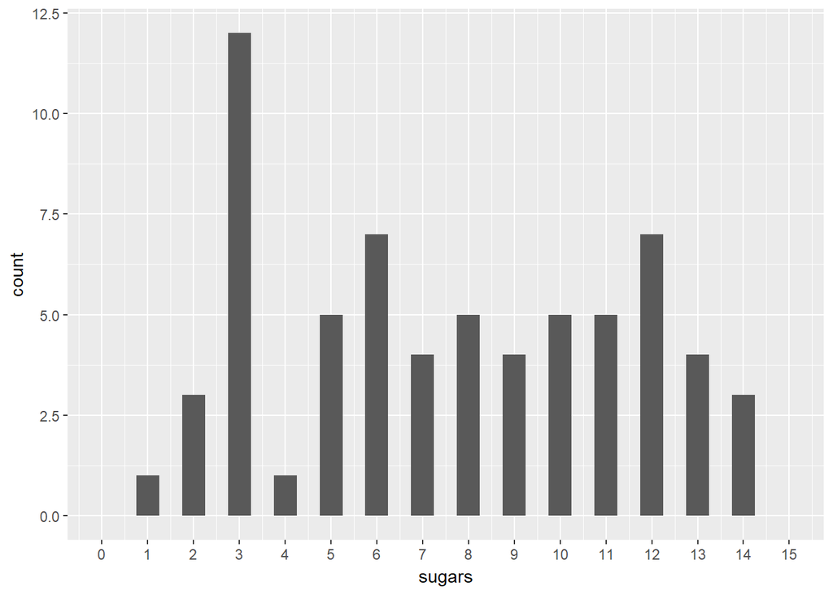

The above plot shows the Distribution of Sugars. There is a spike at 3g so it would appear that this is a target sugar content for many manufacturers. I edited the x axis values to exclude a value of -1 which was obviously an error in data entry as it is an impossible value.

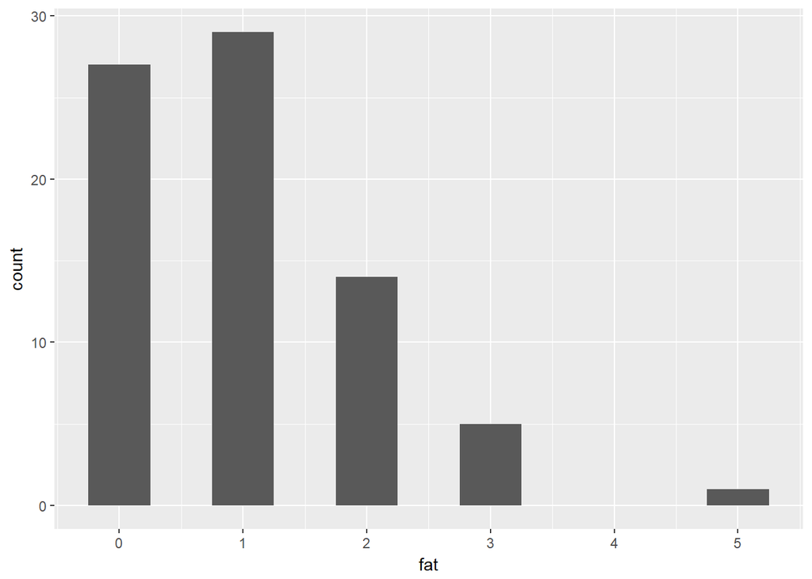

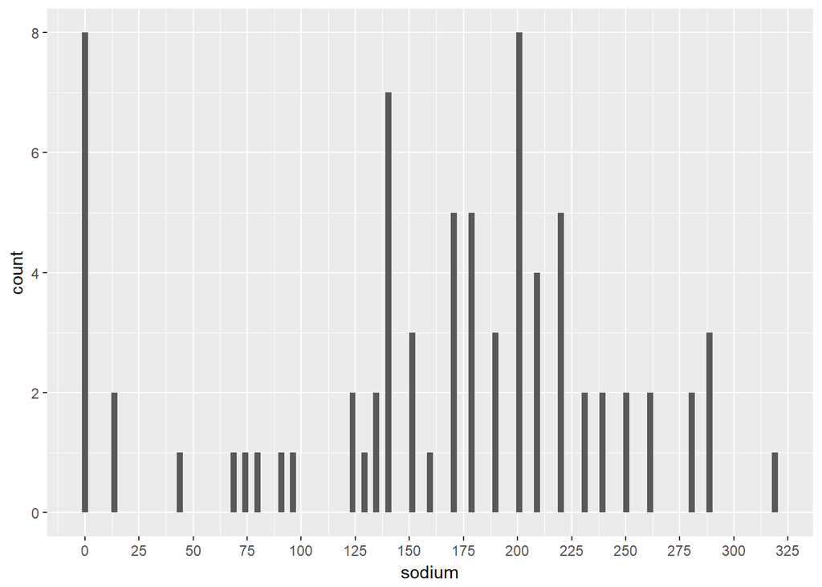

The above plot shows the Distribution of Sodium. Sodium content varies a lot, with 0 and 200mg being spikes, but many other values exist, all the way from 0 to 320.

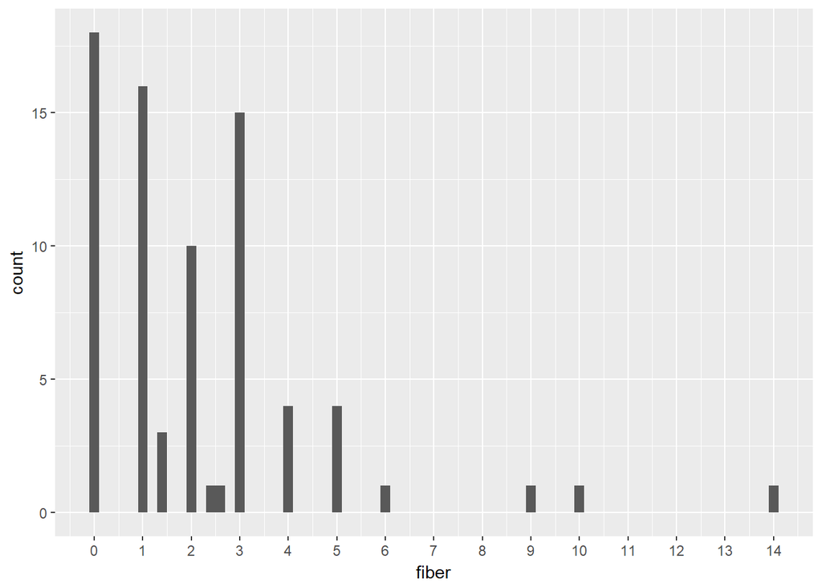

The above plot shows the Distribution of Fiber. We can see that the majority of cereals have very low fiber, with 0 being the most common amount, and we can see that the majority of cereals have 3g or less of fiber.

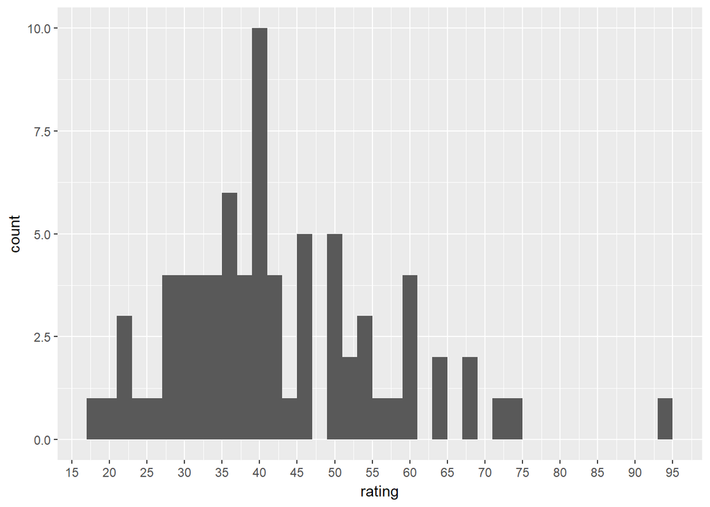

The above plot shows the Distribution of Ratings. We can see that 40 is the most commmon rating, but it’s hard to draw conclusions from the frequencies of the ratings, it would be good to have more data to draw from.

## Univariate Analysis

### What is the structure of your dataset?

The structure of my dataset is 76 rows with 16 original columns, and 7 more that I added.

### What is/are the main feature(s) of interest in your dataset?

I am focusing on sugar, fat, sodium, and fiber and specifically on the relationship between said variables and the overall rating assigned to them.

### What other features in the dataset do you think will help support your /

investigation into your feature(s) of interest?

### Of the features you investigated, were there any unusual distributions?

### Did you perform any operations on the data to tidy, adjust, or change the

### form of the data? If so, why did you do this?

There weren’t any distributions I would characterize as unusual, but I think the distribution of Sodium was intersting in that it was the only one that had a distribution that was widely distributed and more random than the others.

I did not need to adjust or change the form of the data as it was already in a tidy form.

## Bivariate Plots Section

In this section I want to look at the selected nutritional variables by manufacturer, along with their distribution by manufacturer. I think it also might be interesting to look at the relationships between fat and sugar as I have heard that manufacturers try to raise one when they lower the other, and vice versa. I also want to look at the relationship between sugar and fiber as I know that some of the harmful of effects of consuming sugar are mitigated when the sugar is accompanied by an equal or great amount of fiber.

These plots below show nutritional variables by manufacturer

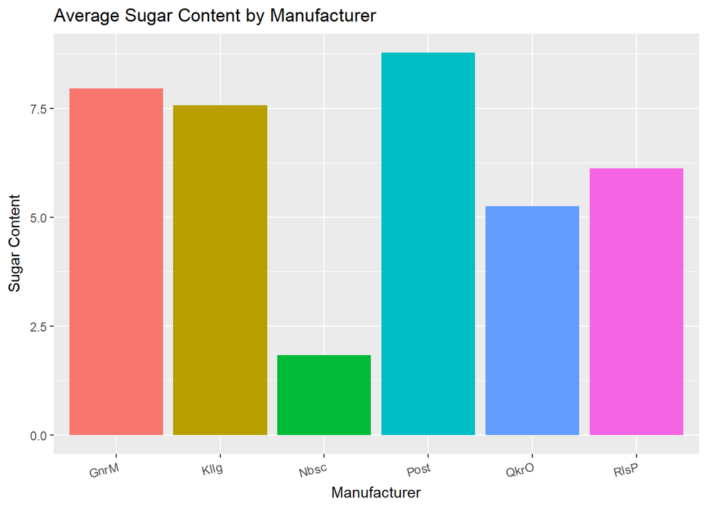

The above plot shows that Nabisco cereals have the lowest average sugar content, while Post cereals have the highest.

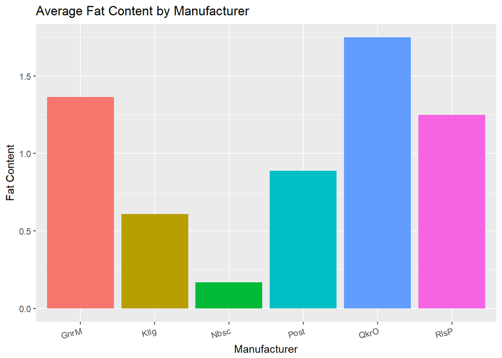

The above plot shows that Nabisco cereals have the lowest average fat content, while Quaker Oats have the highest.

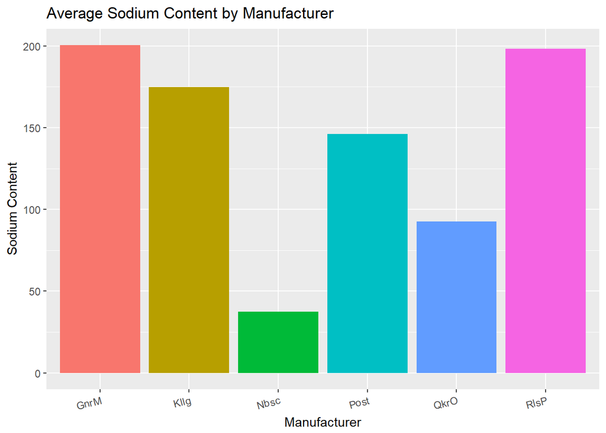

The above plot shows that Nabisco cereals have the lowest average sodium content, while General Mills cereals have the highest.

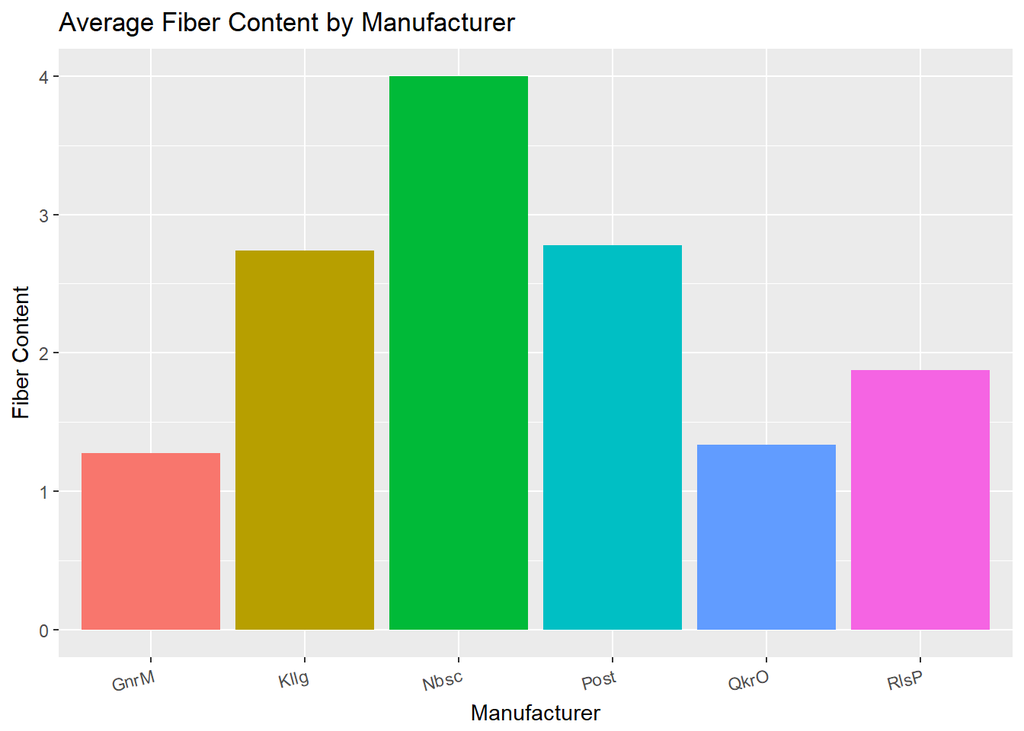

The above plot shows that Nabisco cereals have the highest fiber content, while General Mills cereals have the lowest.

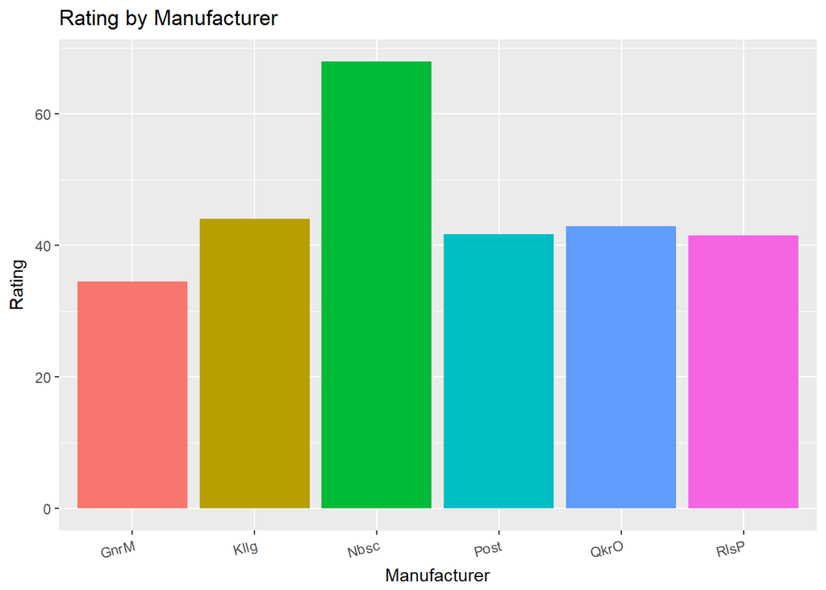

The above plot shows that Nabisco has the highest average cereal rating, while the rest are quite even, although General Mills has the lowest average rating.

The box plots below show distribution of data for selected nutritional variables by manufacturer

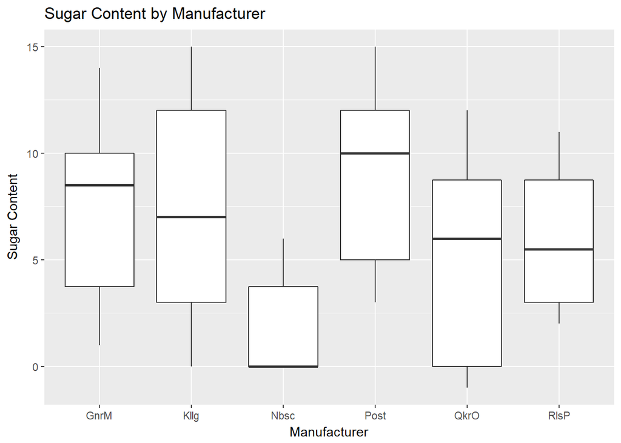

The above plot shows that Nabisco cereals have the smallest distribution of sugar content, while Kellogs and Quaker Oats have the largest. It is interesting that there are no outliers anywhere.

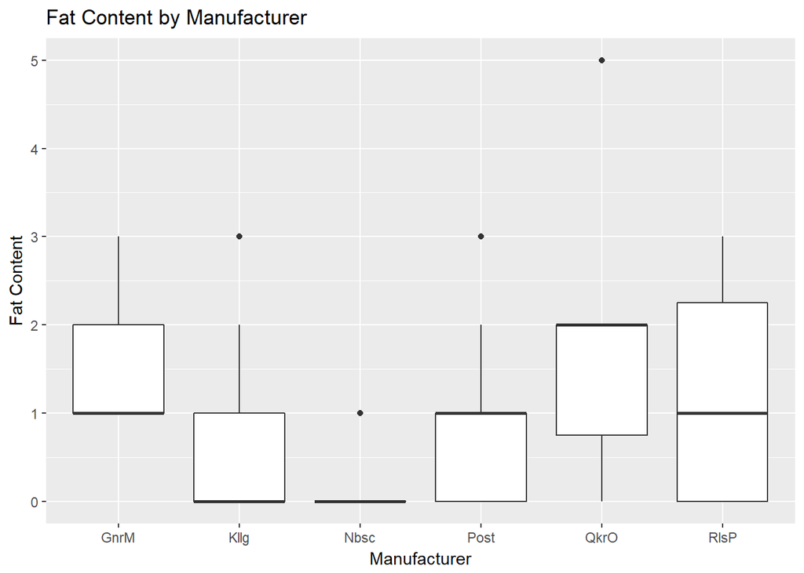

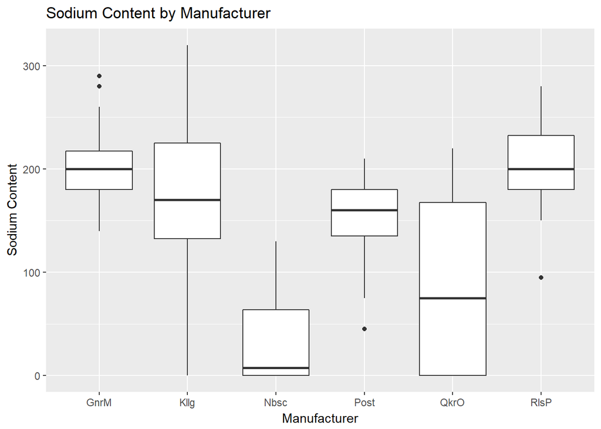

The above plot shows that General Mills cereals have the smallest distribution of sodium content (but with 2 outliers) while Quaker Oats has the largest distribution. Both Ralston Purina and Post have an outlier that contains less sodium than their average.

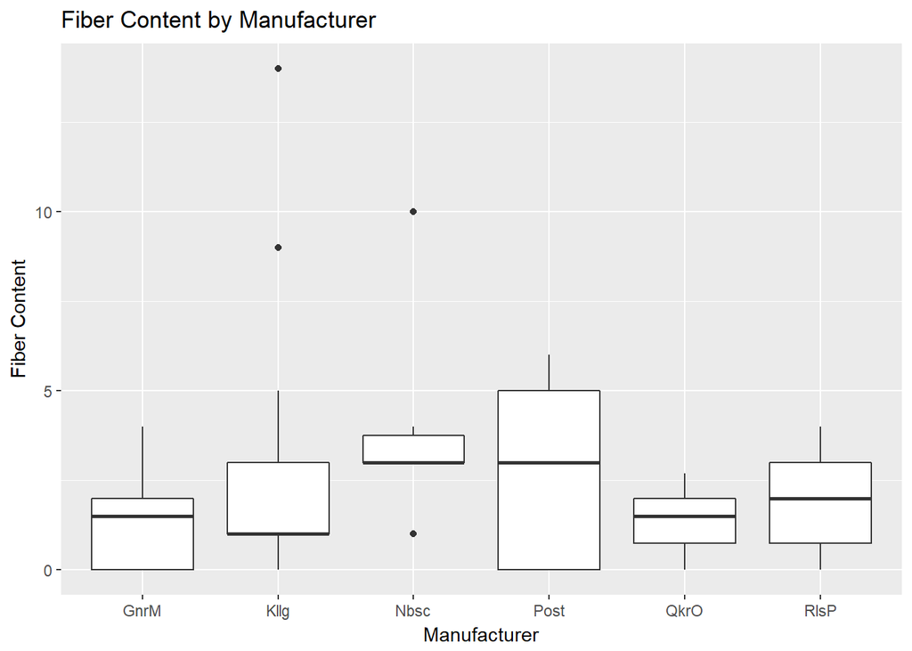

The above plot shows that Nabisco cereals have the smallest distribution, all have relatively high fiber content (with one outlier above and one below), while Post cereals have the largest distribution. Kellogs also has 2 high outliers.

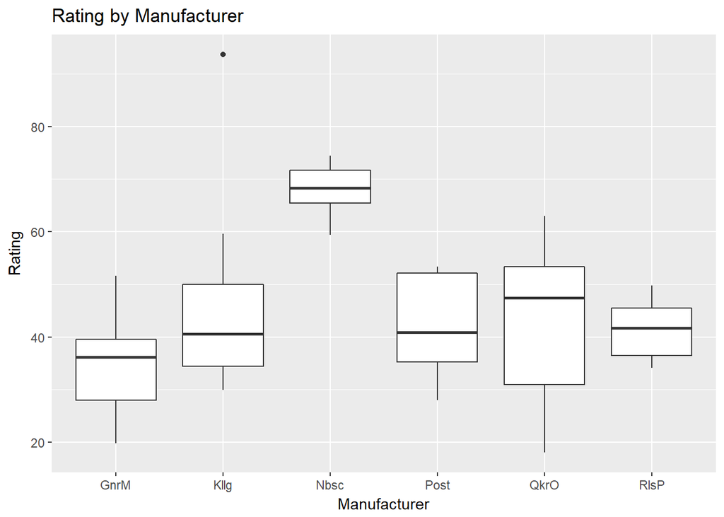

The above plot shows that Nabisco has the highest cereal rating and the lowest distribution, which means they don’t have a single cereal with bad ratings. Quaker Oats had the largest distribution, and Kellogs had one extremly high outlier.

Correlation matrices for selected variables

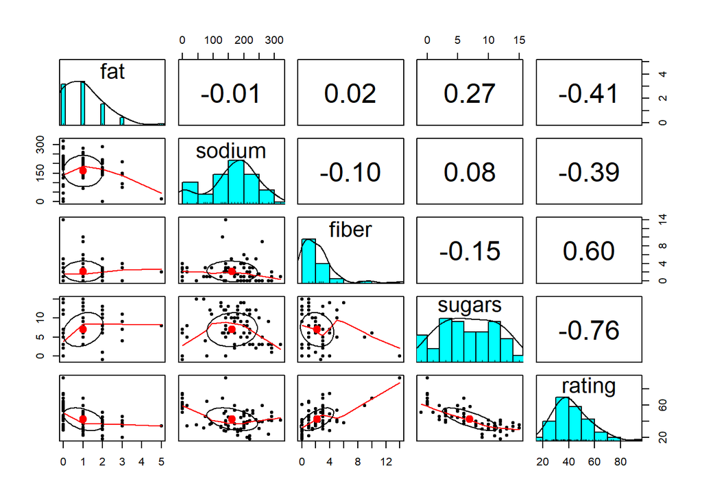

The above correlation matrix shows correlation indices for rating vs. Fat, Sodium, Fiber, and Sugar.

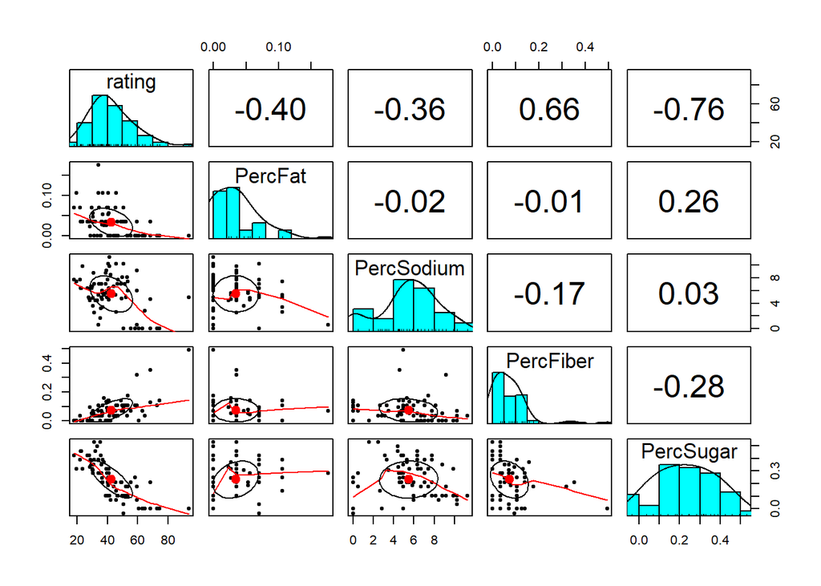

The above correlation matrix shows correlation indices for rating vs. PercFat, PercSodium, PercFiber, and PercSugar. Where Perc is the percentage of content to total weight.

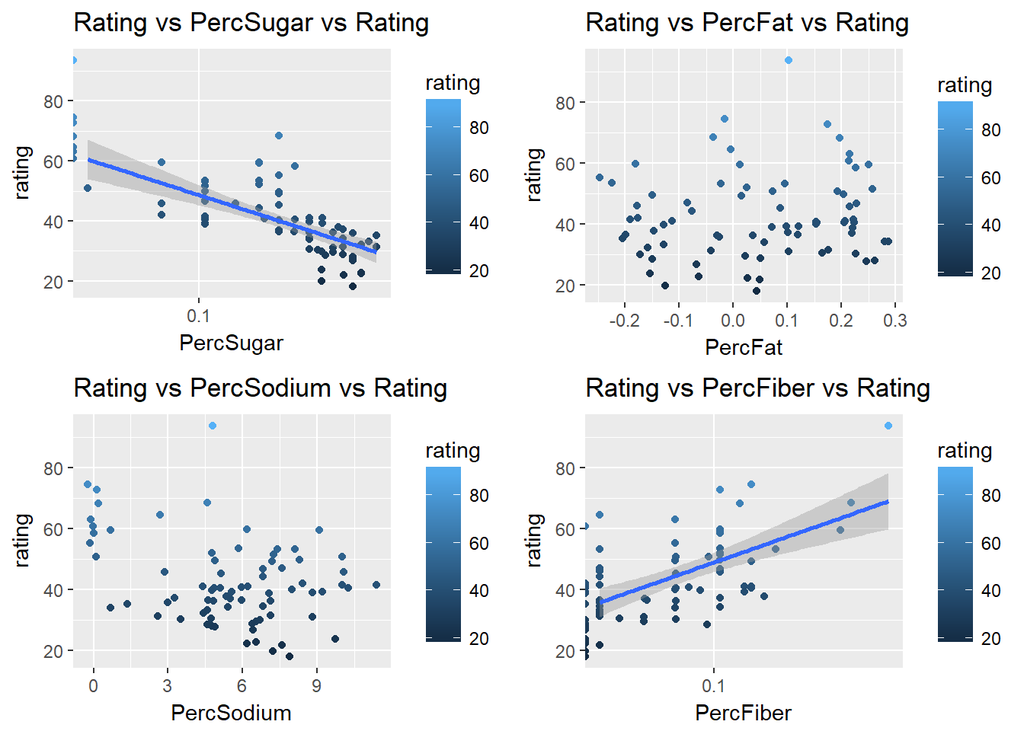

## Bivariate Analysis

### Talk about some of the relationships you observed in this part of the

### investigation. How did the feature(s) of interest vary with other features

### in the dataset?

I found that there was no significant correlation between either Sugar and Fat (weak) or Sugar and Fiber (very weak). I then looked at the correlation between rating and percentage of the selected nutrirional values (since percentage is a more accurate measure then the number of grams/mg since the serving sizes can be different). I found that there is a strong correlation between the rating and both percentage of sugar and percentage of fiber. Although the correlation between rating and percentage of fat and percentage of sodium is lower, I will still use them to contruct my model to predict the rating of a cereal based on its nutrition values.

### Did you observe any interesting relationships between the other features

### (not the main feature(s) of interest)?

Yes, a strong correlation that I wasn´t studying was the correlation betweeen potassium and fiber (0.91)

## Multivariate Plots Section

These plots show the ratio of 1) Sugar to Fat and 2) Sugar to # Fiber, first all on one plot, then faceted by manufacturer.

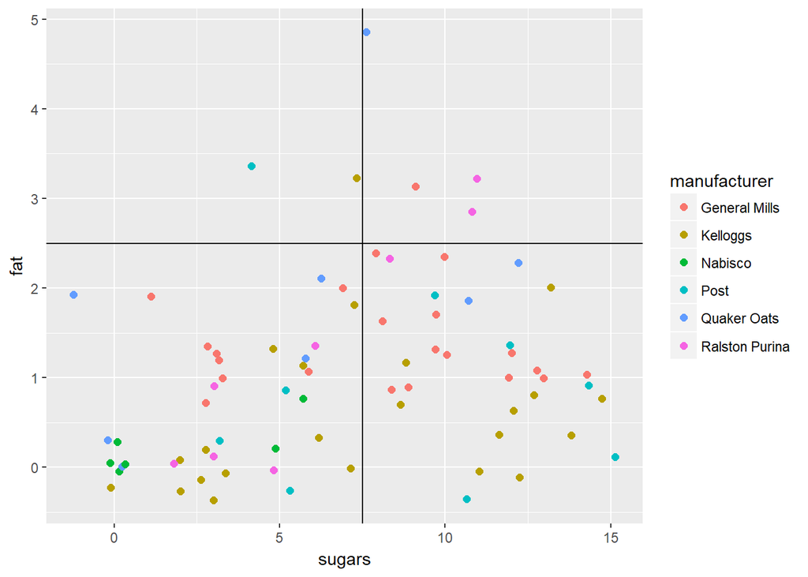

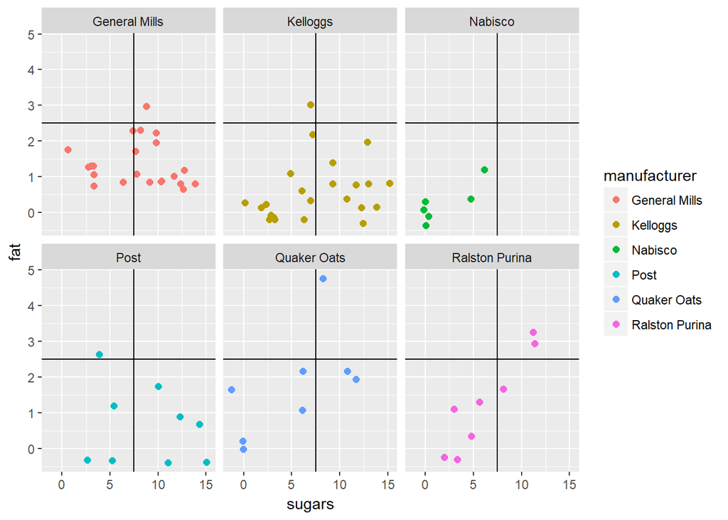

The healthiest quadrant for the above 2 plots is the lower left one, and the  
unhealthiest, the upper right one.

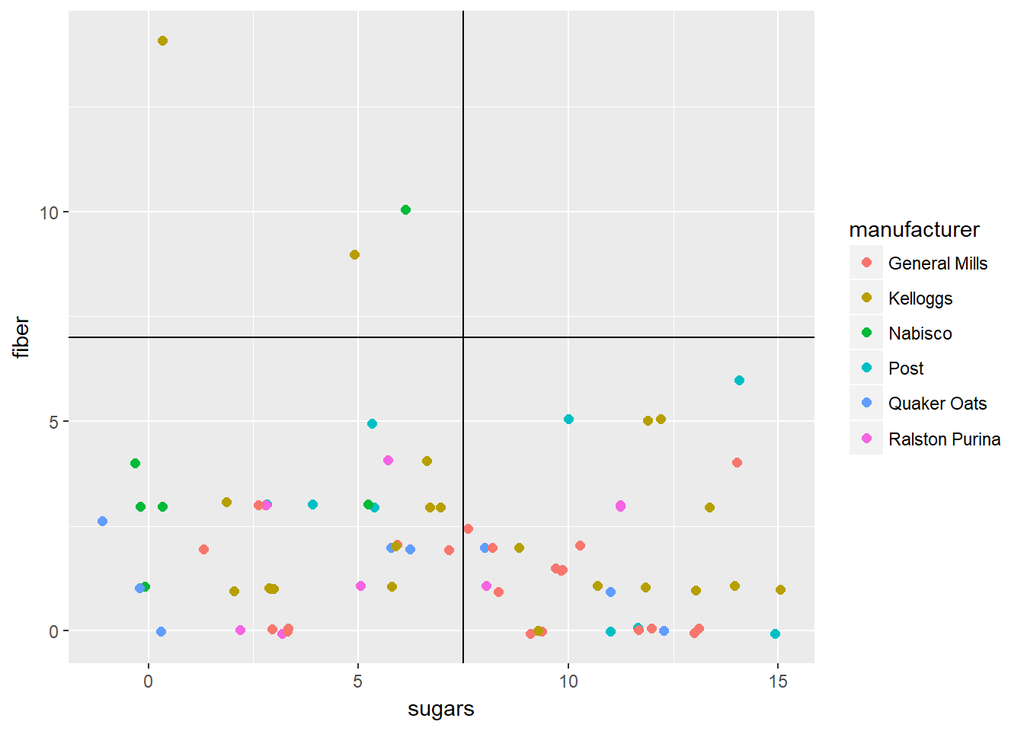

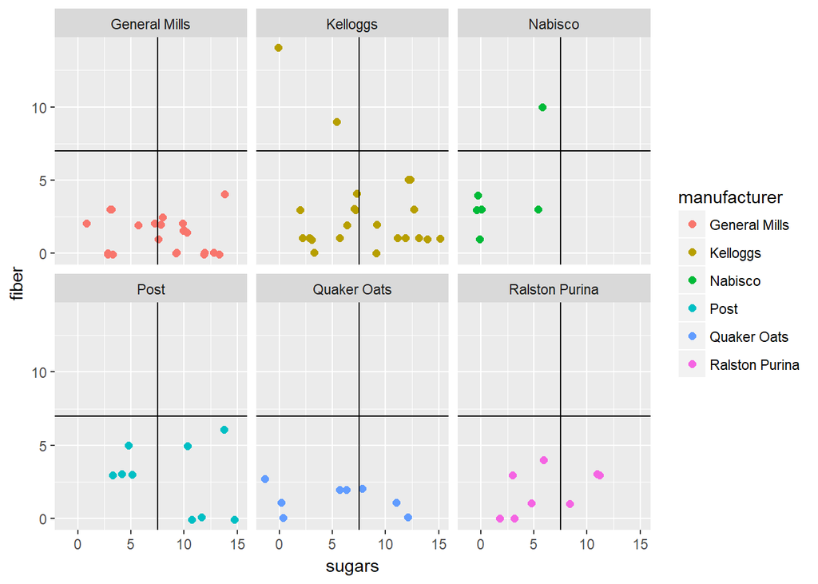

The healthiest quadrant for the above 2 plots is the upper left one, and the unhealthiest, the lower right one.

Correlation Indices for Sugar to Fiber

```
##
##  Pearson's product-moment correlation
##
## data:  cereals$rating and Sugars2FiberRatio
## t = -9.0582, df = 73, p-value = 1.448e-13
## alternative hypothesis: true correlation is not equal to 0
## 95 percent confidence interval:
##  -0.8191676 -0.5994665
## sample estimates:
##        cor
## -0.7274538
```

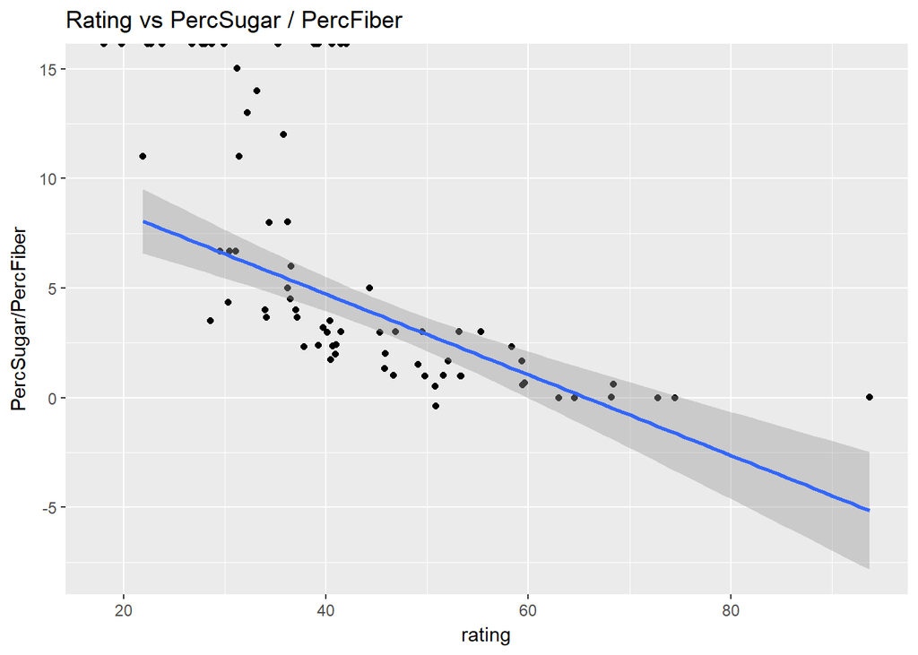

So the ratio of percentage sugars to percentage fiber is a decent predictor of rating, but for my model I will add percentage sodium and percentage fat as well.

```
##
## Call:
## lm(formula = rating ~ PercSugar + PercFiber + PercSodium + PercFat,
##     data = cereals)
##
## Residuals:
##      Min       1Q   Median       3Q      Max
## -12.7668  -2.0694   0.0686   1.9480   7.8653
##
## Coefficients:
##              Estimate Std. Error t value Pr(>|t|)
## (Intercept)   60.1724     1.4028  42.894  < 2e-16 ***
## PercSugar    -54.1640     3.2152 -16.846  < 2e-16 ***
## PercFiber     78.8626     5.6936  13.851  < 2e-16 ***
## PercSodium    -1.3453     0.1548  -8.688 8.85e-13 ***
## PercFat     -101.5538    13.0070  -7.808 3.80e-11 ***
## ---
## Signif. codes:  0 '***' 0.001 '**' 0.01 '*' 0.05 '.' 0.1 ' ' 1
##
## Residual standard error: 3.795 on 71 degrees of freedom
## Multiple R-squared:  0.9311, Adjusted R-squared:  0.9272
## F-statistic: 239.9 on 4 and 71 DF,  p-value: < 2.2e-16
```

```
##
## Calls:
## m1: lm(formula = I(rating) ~ I(PercSugar), data = cereals)
## m2: lm(formula = I(rating) ~ I(PercSugar) + PercFiber, data = cereals)
## m3: lm(formula = I(rating) ~ I(PercSugar) + PercFiber + PercSodium,
##     data = cereals)
## m4: lm(formula = I(rating) ~ I(PercSugar) + PercFiber + PercSodium +
##     PercFat, data = cereals)
##
## ======================================================================
##                       m1           m2           m3           m4
## ----------------------------------------------------------------------
##   (Intercept)       59.519***    50.356***    58.310***    60.172***
##                     (1.977)      (1.712)      (1.871)      (1.403)
##   I(PercSugar)     -73.053***   -60.231***   -60.755***   -54.164***
##                     (7.193)      (5.197)      (4.200)      (3.215)
##   PercFiber                      84.219***    76.241***    78.863***
##                                  (9.393)      (7.694)      (5.694)
##   PercSodium                                  -1.322***    -1.345***
##                                               (0.210)      (0.155)
##   PercFat                                                -101.554***
##                                                           (13.007)
## ----------------------------------------------------------------------
##   R-squared          0.582        0.801        0.872        0.931
##   adj. R-squared     0.577        0.796        0.867        0.927
##   sigma              9.155        6.359        5.138        3.795
##   F                103.143      147.093      163.463      239.931
##   p                  0.000        0.000        0.000        0.000
##   Log-likelihood  -275.111     -246.895     -230.171     -206.618
##   Deviance        6201.939     2951.601     1900.709     1022.670
##   AIC              556.222      501.791      470.342      425.236
##   BIC              563.214      511.114      481.995      439.220
##   N                 76           76           76           76
## ======================================================================
```

## Multivariate Analysis

I observed the rating and how it was affected by the relationship between the percentages of sugar, fat, sodium, and fiber.

### Were there any interesting or surprising interactions between features?

I didn´t find any surprising interactions, the effects on the rating are what I would have predicted.

### OPTIONAL: Did you create any models with your dataset?

Yes, I made a model to predict rating based on PercSugar,PercFiber,PercSodium, and PercFat.the model was very accurate, with an R-squared value of 0.931 with all 4 varibles included.

## Final Plots and Summary

### Plot One

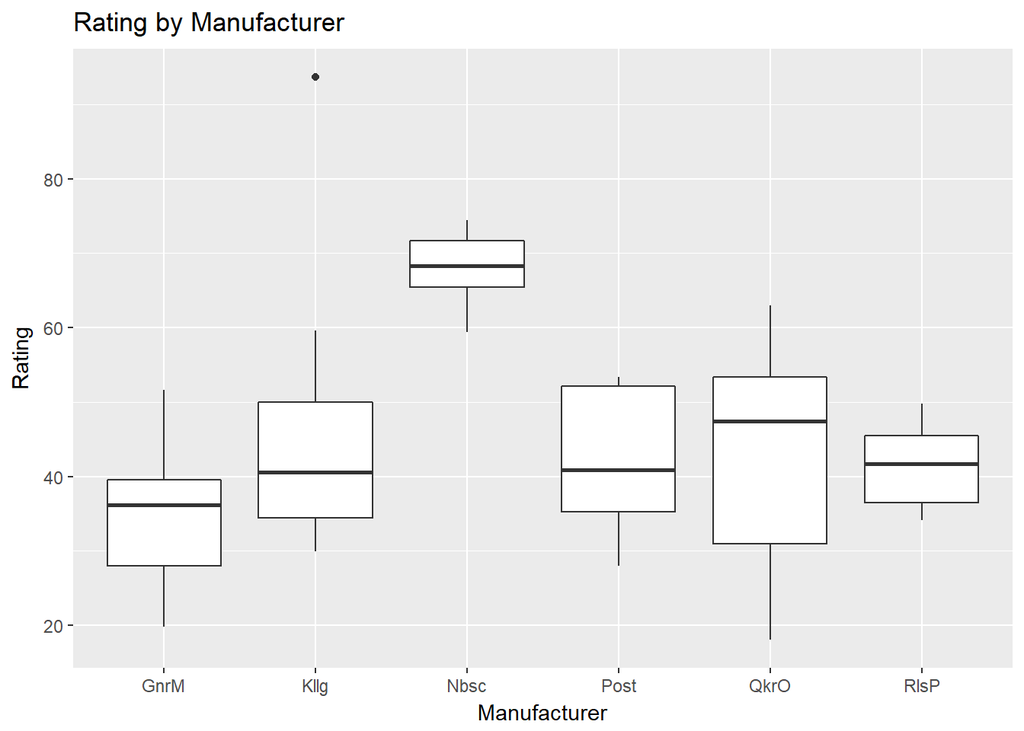

### Plot Two

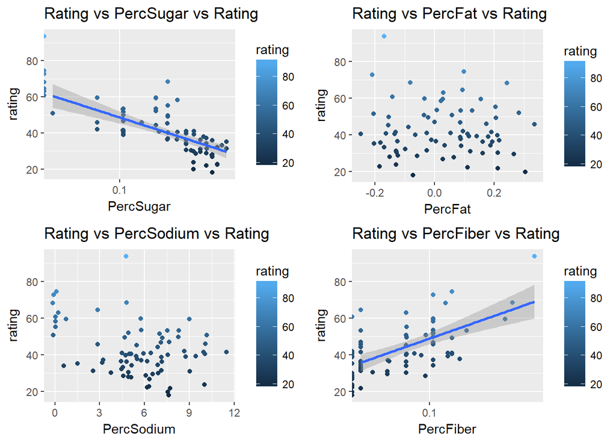

### Description Two

I like these 4 plots together as you can see how their respective correlation indices look like when plotted. It is obvious that PercSugar is closely correlated to rating, while PercFat looks almost randomly distributed.

### Plot Three

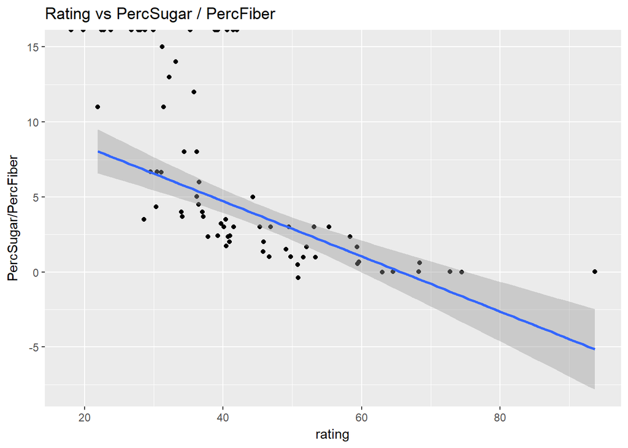

### Description Three

Without trying to find a more complex model, I thought that the ratio of Percentage of Sugar to Percentage of Fiber correlated well with the rating. At the top of the plot, we find all the cereals who had 0 fiber, this is a drawback of using a ratio to plot.

## Reflection

My overall conclusion is 1) that Nabisco makes the most nutritious cereals, by far, and 2) that the rating for each cereal can be closely approximated by using a predictive model of PercSugar + PercFat +PercSodium + PercFiber.

Some of the challenges I encountered were: not knowing what year the study was from, not knowing where or how the rating came from, dealing with a relatively small and incomplete dataset, and deciding what the most relevant columns were to cereal nutrition. Ideally, in the future, the dataset would include many more cereals so that there is more data to base conclusions off of. It would be interesting in the future to examine the relationship between ratings and manufacturer, to see if there is any favoritism involved, or if the ratings are generated from a fixed formula.

## Resources used

https://www.kaggle.com/crawford/80-cereals

https://stackoverflow.com/questions/18882206/change-outline-and-fill-colors-of -histogram-with-qplot

https://stackoverflow.com/questions/40711980/r-ggplot2-fit-curve-to-scatter-plot

https://stackoverflow.com/questions/22282531/how-to-compute-correlations-between -all-columns-in-r-and-detect-highly-correlate

https://stackoverflow.com/questions/8214303/conditional-replacement-of-values-in -a-data-frame

https://stackoverflow.com/questions/36590230/how-to-remove-rows-with-inf-from-a- dataframe-in-r/36590347